# Module 4 Report

450132759 / 450463055

October 31, 2018

## Introduction

Flagging spam email for users is a crucial part of any email service, as it offers protection for users from phishing scams or from nefarious companies from flooding a user’s inbox and drowing out legitimate emails. Fortunately, spam emails frequently contain certain characters or phrases that can easily be identified by scanning incoming emails. We obtain the data set from the University of Irvine Machine Learning Repository, which contains percentages of appearances of 56 different words or characters in an email. We also know that each of the 4601 emails in our data set is flagged as either spam or nonspam. As we do not want to misclassify legitimate emails as spam emails, our performance metric is the specificity of our models. We will start by fitting different models to our dataset and then identify which model gives the highest specificity.

## Analysis

```r
library(tidyverse)
library(gridExtra)
library(emmeans)
library(ggfortify)
# install.packages('kernlab')
data(spam, package = "kernlab")
```

```r
spam <- spam %>% mutate(type = ifelse(type == "spam", 1, 0))
spam$type = as.factor(spam$type)
```

Here, we changed the spam and nonspam labels to 1 and 0 respectively, and specified them as factors.

### Decision Tree

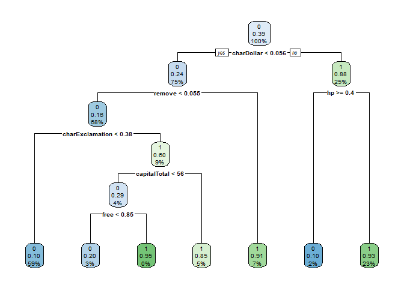

```r
#install.packages("rpart")
#install.packages("rpart.plot")
library(rpart)
library(rpart.plot)
tree = rpart(factor(type) ~ ., data = spam, method = "class")
rpart.plot(tree)
```

```r
library(caret)
predicted = predict(tree, type = "class")
cm = confusionMatrix(
  data = predicted,
  reference = factor(spam$type),
  positive = "1")
cm$overall[1] %>% round(2)
```

```
## Accuracy
##      0.9
```

```r
cm$byClass[2]
```

```
## Specificity
##   0.9519369
```

In sample performance of decision tree model gives an accuracy of 90.26%. We also observe a specificity value of 0.9519 and a sensitivity value of 0.8268. The high specificity value is especially desirable in this case, as it indicates a low false positive rate. This means that clean emails are rarely classified as spam.

```r
train(type ~ ., data = spam,
     method = "rpart", trControl = trainControl(method = "cv", number = 10))
```

```
## CART
##
## 4601 samples
##   57 predictor
##    2 classes: '0', '1'
##
## No pre-processing
## Resampling: Cross-Validated (10 fold)
## Summary of sample sizes: 4141, 4141, 4141, 4140, 4141, 4140, ...
## Resampling results across tuning parameters:
##
##   cp          Accuracy   Kappa
##   0.04302261  0.8574151  0.6976564
##   0.14892443  0.7861304  0.5438191
##   0.47655819  0.7385656  0.4084572
##
## Accuracy was used to select the optimal model using the largest value.
## The final value used for the model was cp = 0.04302261.
```

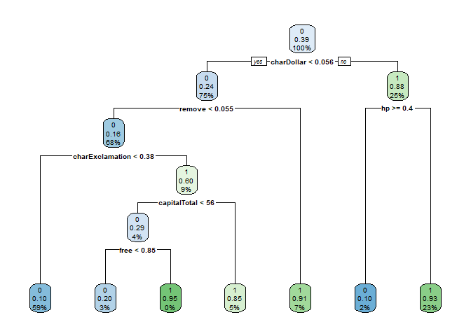

```r
tree_cp = rpart(factor(type) ~ ., data = spam, method = "class", control = rpart.control(cp = 0.043))
rpart.plot(tree)
```

```r
library(caret)
predicted_cp = predict(tree_cp, type = "class")
confusionMatrix(
  data = predicted_cp,
  reference = factor(spam$type),
  positive = "1")
```

```
## Confusion Matrix and Statistics
##
##           Reference
## Prediction    0    1
##          0 2592  327
##          1  196 1486
##
##                Accuracy : 0.8863
##                  95% CI : (0.8768, 0.8954)
##     No Information Rate : 0.606
##     P-Value [Acc > NIR] : < 2.2e-16
##
##                   Kappa : 0.7589
##  Mcnemar's Test P-Value : 1.312e-08
##
##             Sensitivity : 0.8196
##             Specificity : 0.9297
##          Pos Pred Value : 0.8835
##          Neg Pred Value : 0.8880
##              Prevalence : 0.3940
##          Detection Rate : 0.3230
##    Detection Prevalence : 0.3656
##       Balanced Accuracy : 0.8747
##
##        'Positive' Class : 1
##
```

While this model suffers a drop of about 2% in both accuracy and specificity, the improved out-of-sample performance is preferred, as it allows the spam detection to deal with a wider range of emails, making it a more robust system.

### Random Forest

Now, we look to fit a random forest model.

```r
library(randomForest)
tree_rf = randomForest(type ~ ., spam)
tree_rf
```

```
##
## Call:
##  randomForest(formula = type ~ ., data = spam)
##                Type of random forest: classification
##                      Number of trees: 500
## No. of variables tried at each split: 7
##
##         OOB estimate of  error rate: 4.52%
## Confusion matrix:
##      0    1 class.error
## 0 2707   81  0.02905308
## 1  127 1686  0.07004964
```

```r
predicted_cp = predict(tree_rf, type = "class")
confusionMatrix(
  data = predicted_cp,
  reference = factor(spam$type),
  positive = "1")$byClass[2]
```

```
## Specificity
##   0.9709469
```

### Logistic Regression

Here, we seek to fit a binomial logistic model. We find a suitable model using backwards and forwards AIC.

```r
# install.packages("stargazer")
# library(stargazer)
spam_full_glm <- glm(type ~ ., family = binomial, data = spam)
spam_bw_aic = step(spam_full_glm,direction = "backward",trace=TRUE)
spam_null_glm <- glm(type ~ 1, family = binomial, data = spam)
spam_fw_aic = step(spam_full_glm,direction = "forward",trace=TRUE)
```

```r
spam = spam %>% mutate(pred_bw = predict(spam_bw_aic, type = "response"),
         pred_bw = round(pred_bw))

mean(spam$type != spam$pred_bw)
```

```
## [1] 0.06781135
```

```r
library(caret)
confusion.glm = confusionMatrix(
  data = as.factor(spam$pred_bw),
  reference = as.factor(spam$type),
  positive = "1")
confusion.glm$overall[1]
```

```
##  Accuracy
## 0.9321887
```

```r
confusion.glm$byClass[2]
```

```
## Specificity
##   0.9573171
```

```r
# stargazer::stargazer(fm, step_model, type = "html", column.labels = c("Full model",
    # "Stepwise model"))

spam = spam %>% mutate(pred_fw = predict(spam_fw_aic, type = "response"),
         pred_fw = round(pred_fw))

mean(spam$type != spam$pred_fw)
```

```
## [1] 0.06868072
```

```r
library(caret)
confusion.glm = confusionMatrix(
  data = as.factor(spam$pred_fw),
  reference = as.factor(spam$type),
  positive = "1")
confusion.glm$overall[1]
```

```
##  Accuracy
## 0.9313193
```

```r
confusion.glm$byClass[2]
```

```
## Specificity
##    0.956241
```

We observe a 93.22% accuracy from the backwards AIC logistic model, and a 93.13% accuracy from the forwards AIC logistic model. Furthermore, we observed specificity values of 95.73% and 95.62%, respectively.

```r
spam_bw_aic$model %>% names()
```

```
##  [1] "type"            "make"            "address"
##  [4] "num3d"           "our"             "over"
##  [7] "remove"          "internet"        "order"
## [10] "mail"            "will"            "addresses"
## [13] "free"            "business"        "you"
## [16] "credit"          "your"            "font"
## [19] "num000"          "money"           "hp"
## [22] "hpl"             "george"          "num650"
## [25] "lab"             "data"            "num85"
## [28] "technology"      "parts"           "pm"
## [31] "cs"              "meeting"         "original"
## [34] "project"         "re"              "edu"
## [37] "table"           "conference"      "charSemicolon"
## [40] "charExclamation" "charDollar"      "charHash"
## [43] "capitalLong"     "capitalTotal"
```

### Nearest Neighbour

Here, we look at fitting a nearest neighbour model with k = 5.

```r
knn5 = class::knn(train = spam, test = spam, cl = spam$type, k = 5)
confusionMatrix(knn5, spam$type, positive = "1")$byClass[2]
```

```
## Specificity
##   0.9099713
```

```r
caret::confusionMatrix(knn5, spam$type)$table
```

```
##           Reference
## Prediction    0    1
##          0 2537  278
##          1  251 1535
```

```r
caret::confusionMatrix(knn5, spam$type)$overall[1] %>% round(2)
```

```
## Accuracy
##     0.89
```

We now check that k = 5 is the value of k that gives the best accuracy by using repeated cross-validation.

```r
fitControl = trainControl(method = "repeatedcv", number = 5, repeats = 10)
knnFit1 = train(type ~ ., data = spam, method = "knn", trControl = fitControl,
    tuneLength = 10)
knnFit1
```

```
## k-Nearest Neighbors
##
## 4601 samples
##   59 predictor
##    2 classes: '0', '1'
##
## No pre-processing
## Resampling: Cross-Validated (5 fold, repeated 10 times)
## Summary of sample sizes: 3680, 3681, 3681, 3681, 3681, 3680, ...
## Resampling results across tuning parameters:
##
##   k   Accuracy   Kappa
##    5  0.8112136  0.6032843
##    7  0.8045421  0.5885751
##    9  0.7994994  0.5774437
##   11  0.7956519  0.5690147
##   13  0.7895660  0.5563181
##   15  0.7861538  0.5491449
##   17  0.7818940  0.5399726
##   19  0.7791990  0.5343777
##   21  0.7763289  0.5284893
##   23  0.7731560  0.5217455
##
## Accuracy was used to select the optimal model using the largest value.
## The final value used for the model was k = 5.
```

Here, we look at the out of sample performance for kNN, decision trees, and logistic regression model.

```r
knn_acc = max(knnFit1$results$Accuracy)
# decision tree
rpartFit1 = train(type ~ ., data = spam, method = "rpart", trControl = fitControl)
rpart_acc = max(rpartFit1$results$Accuracy)
# random forests
# rfFit1 = train(type ~ ., data = spam, method = "rf", trControl = trainControl(method = "repeatedcv", number = 5, repeats = 1))
# rf_acc = max(rfFit1$results$Accuracy)
# rf_acc
# # glm
glmFit1 = train(type ~ ., data = spam, method = "glm", family = "binomial",
    trControl = fitControl)
glm_acc = glmFit1$results$Accuracy
c(knn_acc,rpart_acc,glm_acc)
```

```
## [1] 0.8127369 0.9348178 0.9297540
```

We can see that the decision tree model gives the best accuracy, followed by the logistic regression model and the k-nearest neighbour model.

## Conclusion

[output not shown]